# Analyse des vulnerabilites ANSSI / CERT-FR

**Exploration, visualisation et modelisation des bulletins de securite du CERT-FR**

Ce notebook constitue le 3e livrable du projet. Il s'appuie sur le fichier `output/data_consolidee.csv` produit par le pipeline Python (`extraction -> enrichissement -> consolidation`). Les donnees combinent :

- les **bulletins du CERT-FR** (avis & alertes) ;
- l'enrichissement **MITRE** (description, score **CVSS**, type **CWE**, produits affectes) ;
- l'enrichissement **FIRST** (score **EPSS**, probabilite d'exploitation).

## Sommaire

1. **Chargement** du fichier CSV consolide
2. **Exploration** du DataFrame (structure, valeurs manquantes, granularite)
3. **Visualisations & analyses** (distributions, classements, correlations, temporel)
4. **Modele supervise** : classification de la haute severite (CVSS >= 7)
5. **Modele non supervise** : segmentation des vulnerabilites (KMeans)
6. **Validation** des modeles et **conclusion**

> Les scores **CVSS** (gravite, 0-10) et **EPSS** (probabilite d'exploitation, 0-1) mesurent deux choses differentes : c'est cette complementarite que l'on exploite dans les analyses et les modeles.

## 1. Imports et configuration

```python
import warnings
from pathlib import Path

import numpy as np
import pandas as pd
import matplotlib.pyplot as plt
import seaborn as sns

warnings.filterwarnings("ignore")

# Rendu des figures dans le notebook
%matplotlib inline
sns.set_theme(style="whitegrid", palette="deep")
plt.rcParams["figure.figsize"] = (10, 5)
plt.rcParams["axes.titlesize"] = 13
plt.rcParams["figure.dpi"] = 110

RANDOM_STATE = 42
np.random.seed(RANDOM_STATE)

print("Librairies chargees.")
print("pandas", pd.__version__, "| numpy", np.__version__)
```

```
Librairies chargees.
pandas 3.0.3 | numpy 2.4.6
```

## 2. Chargement du fichier CSV consolide

*(livrable 3.a)*

Le notebook peut etre lance depuis la racine du projet **ou** depuis le dossier `notebooks/` : on recherche le CSV dans les deux emplacements habituels.

```python
CANDIDATS = [
    Path("output/data_consolidee.csv"),
    Path("../output/data_consolidee.csv"),
]
CSV = next((p for p in CANDIDATS if p.exists()), None)
if CSV is None:
    raise FileNotFoundError(
        "data_consolidee.csv introuvable. Lancez d'abord `python main.py` "
        "a la racine du projet pour generer le CSV consolide."
    )

df = pd.read_csv(CSV)

# Typage : numerique pour CVSS/EPSS, datetime pour la date du bulletin.
df["cvss"] = pd.to_numeric(df["cvss"], errors="coerce")
df["epss"] = pd.to_numeric(df["epss"], errors="coerce")
df["date"] = pd.to_datetime(df["date"], errors="coerce", utc=True)
df["annee"] = df["date"].dt.year

print(f"Fichier charge : {CSV}")
print(f"Dimensions     : {df.shape[0]:,} lignes x {df.shape[1]} colonnes")
df.head()
```

```
Fichier charge : ../output/data_consolidee.csv
Dimensions     : 113,624 lignes x 16 colonnes
```

|  | id_anssi | title_anssi | type | date | cve | cvss | base_severity | cwe | cwe_desc | epss | link | description | vendor | product | versions | annee |
| --- | --- | --- | --- | --- | --- | --- | --- | --- | --- | --- | --- | --- | --- | --- | --- | --- |
| 0 | CERTFR-2025-AVI-0925 | Vulnérabilité dans les produits Belden | Avis | 2025-10-27 00:00:00+00:00 | CVE-2024-3596 | NaN | Inconnue | NaN | CWE-328: Use of Weak Hash | 0.22162 | https://www.cert.ssi.gouv.fr/avis/CERTFR-2025-... | RADIUS Protocol under RFC 2865 is susceptible ... | IETF | RFC | 2865 | 2025 |
| 1 | CERTFR-2025-AVI-0119 | Multiples vulnérabilités dans les produits Intel | Avis | 2025-02-12 00:00:00+00:00 | CVE-2021-37577 | NaN | Inconnue | NaN | NaN | 0.00040 | https://www.cert.ssi.gouv.fr/avis/CERTFR-2025-... | Bluetooth LE and BR/EDR Secure Connections pai... | NaN | NaN | NaN | 2025 |
| 2 | CERTFR-2025-AVI-0119 | Multiples vulnérabilités dans les produits Intel | Avis | 2025-02-12 00:00:00+00:00 | CVE-2023-25191 | NaN | Inconnue | NaN | NaN | 0.00222 | https://www.cert.ssi.gouv.fr/avis/CERTFR-2025-... | AMI MegaRAC SPX devices allow Password Disclos... | NaN | NaN | NaN | 2025 |
| 3 | CERTFR-2025-AVI-0119 | Multiples vulnérabilités dans les produits Intel | Avis | 2025-02-12 00:00:00+00:00 | CVE-2023-25192 | NaN | Inconnue | NaN | NaN | 0.00216 | https://www.cert.ssi.gouv.fr/avis/CERTFR-2025-... | AMI MegaRAC SPX devices allow User Enumeration... | NaN | NaN | NaN | 2025 |
| 4 | CERTFR-2025-AVI-0119 | Multiples vulnérabilités dans les produits Intel | Avis | 2025-02-12 00:00:00+00:00 | CVE-2023-29164 | 5.8 | Moyenne | NaN | Escalation of Privilege | 0.00027 | https://www.cert.ssi.gouv.fr/avis/CERTFR-2025-... | Improper access control in BMC Firmware for th... | NaN | Intel(R) Server Board S2600WF, Intel(R) Server... | See references | 2025 |

## 3. Exploration du DataFrame

*(livrable 3.b)*

### 3.1 Structure et types

```python
df.info()
```

```
<class 'pandas.DataFrame'>
RangeIndex: 113624 entries, 0 to 113623
Data columns (total 16 columns):
 #   Column         Non-Null Count   Dtype
---  ------         --------------   -----
 0   id_anssi       113624 non-null  str
 1   title_anssi    113624 non-null  str
 2   type           113624 non-null  str
 3   date           113624 non-null  datetime64[us, UTC]
 4   cve            113624 non-null  str
 5   cvss           23427 non-null   float64
 6   base_severity  113624 non-null  str
 7   cwe            22269 non-null   str
 8   cwe_desc       32818 non-null   str
 9   epss           112639 non-null  float64
 10  link           113624 non-null  str
 11  description    112625 non-null  str
 12  vendor         105488 non-null  str
 13  product        108235 non-null  str
 14  versions       106670 non-null  str
 15  annee          113624 non-null  int32
dtypes: datetime64[us, UTC](1), float64(2), int32(1), str(12)
memory usage: 13.4 MB
```

### 3.2 Granularite des donnees

Le CSV est a la granularite **(bulletin x CVE)** : une meme CVE peut apparaitre dans plusieurs bulletins (et inversement). Pour la plupart des analyses et pour le Machine Learning, on raisonne au niveau de la **CVE unique** afin d'eviter de compter plusieurs fois la meme vulnerabilite.

```python
print(f"Lignes (bulletin x CVE) : {len(df):,}")
print(f"Bulletins uniques       : {df['id_anssi'].nunique():,}")
print(f"CVE uniques             : {df['cve'].nunique():,}")
print(f"Periode couverte        : {df['date'].min()}  ->  {df['date'].max()}")

# DataFrame dedoublonne au niveau CVE (on garde la 1re occurrence enrichie).
cve = df.sort_values("date").drop_duplicates("cve", keep="first").reset_index(drop=True)
print(f"\nDataFrame CVE unique : {cve.shape[0]:,} lignes")
```

```
Lignes (bulletin x CVE) : 113,624
Bulletins uniques       : 2,860
CVE uniques             : 31,564
Periode couverte        : 2024-01-02 00:00:00+00:00  ->  2026-06-09 00:00:00+00:00

DataFrame CVE unique : 31,564 lignes
```

### 3.3 Statistiques descriptives des scores

```python
cve[["cvss", "epss"]].describe().T
```

|  | count | mean | std | min | 25% | 50% | 75% | max |
| --- | --- | --- | --- | --- | --- | --- | --- | --- |
| cvss | 13447.0 | 6.601101 | 1.719919 | 0.00000 | 5.40000 | 6.80000 | 7.80000 | 10.0000 |
| epss | 31127.0 | 0.014538 | 0.085831 | 0.00001 | 0.00023 | 0.00051 | 0.00164 | 0.9447 |

### 3.4 Valeurs manquantes

Tous les bulletins ne sont pas enrichissables : certaines CVE n'ont pas de score CVSS publie par MITRE, d'autres pas de produit identifie. On quantifie ces manques (au niveau CVE unique) car ils conditionnent les analyses suivantes.

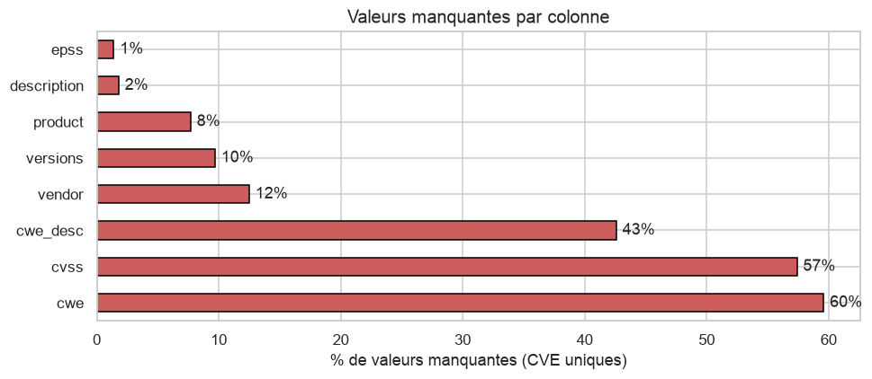

|  | pct_manquant |
| --- | --- |
| cwe | 59.6 |
| cvss | 57.4 |
| cwe_desc | 42.6 |
| vendor | 12.5 |
| versions | 9.7 |
| product | 7.7 |
| description | 1.8 |
| epss | 1.4 |

```python
manquantes = (cve.isna().mean() * 100).round(1).sort_values(ascending=False)
manquantes = manquantes[manquantes > 0]

fig, ax = plt.subplots(figsize=(9, 4))
manquantes.plot(kind="barh", color="indianred", edgecolor="black", ax=ax)
ax.set_xlabel("% de valeurs manquantes (CVE uniques)")
ax.set_title("Valeurs manquantes par colonne")
for i, v in enumerate(manquantes.values):
    ax.text(v + 0.5, i, f"{v:.0f}%", va="center")
plt.tight_layout()
plt.show()

manquantes.to_frame("pct_manquant")
```

## 4. Visualisations et analyses

*(livrable 3.c)*

### 4.1 Repartition des niveaux de severite

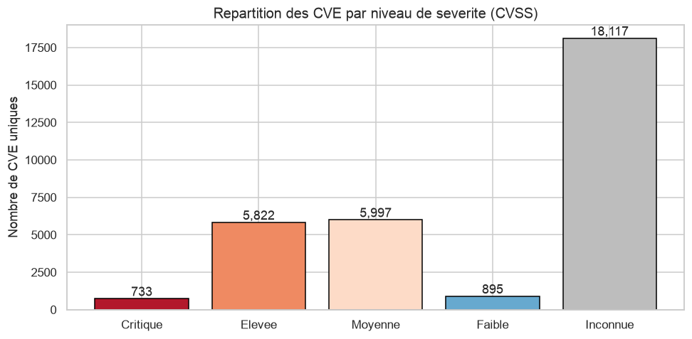

```python
ordre = ["Critique", "Elevee", "Moyenne", "Faible", "Inconnue"]
couleurs = {"Critique": "#b2182b", "Elevee": "#ef8a62", "Moyenne": "#fddbc7",
            "Faible": "#67a9cf", "Inconnue": "#bdbdbd"}
sev = cve["base_severity"].value_counts().reindex(ordre).dropna()

fig, ax = plt.subplots(figsize=(9, 4.5))
ax.bar(sev.index, sev.values, color=[couleurs[s] for s in sev.index], edgecolor="black")
ax.set_ylabel("Nombre de CVE uniques")
ax.set_title("Repartition des CVE par niveau de severite (CVSS)")
for i, v in enumerate(sev.values):
    ax.text(i, v + max(sev.values) * 0.01, f"{v:,}", ha="center")
plt.tight_layout()
plt.show()
```

### 4.2 Distribution des scores CVSS

Le barème ANSSI/CVSS : *Faible* (< 4), *Moyenne* (4-7), *Elevee* (7-9), *Critique* (>= 9).

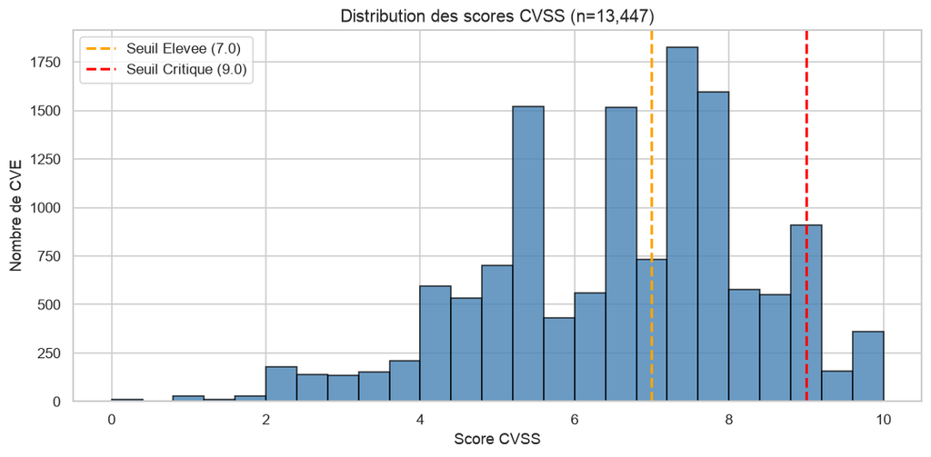

```
CVSS moyen : 6.60 | median : 6.80
```

```python
data = cve["cvss"].dropna()
fig, ax = plt.subplots(figsize=(10, 5))
ax.hist(data, bins=25, color="steelblue", edgecolor="black", alpha=0.8)
ax.axvline(7.0, color="orange", linestyle="--", lw=2, label="Seuil Elevee (7.0)")
ax.axvline(9.0, color="red", linestyle="--", lw=2, label="Seuil Critique (9.0)")
ax.set_xlabel("Score CVSS"); ax.set_ylabel("Nombre de CVE")
ax.set_title(f"Distribution des scores CVSS (n={len(data):,})")
ax.legend()
plt.tight_layout(); plt.show()

print(f"CVSS moyen : {data.mean():.2f} | median : {data.median():.2f}")
```

### 4.3 Distribution des scores EPSS

L'EPSS est tres asymetrique : la grande majorite des vulnerabilites a une faible probabilite d'exploitation, mais une minorite presente un risque eleve. On utilise une echelle logarithmique pour le lisibiliser.

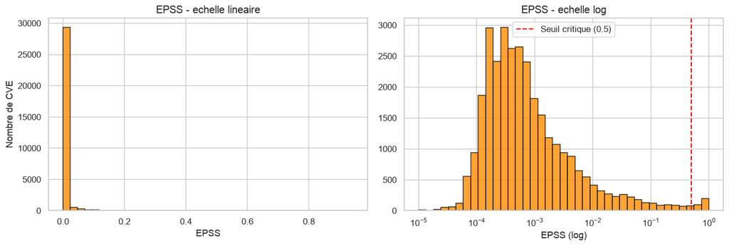

```
CVE avec EPSS >= 0.5 (exploitation probable) : 325 (1.0%)
```

```python
data = cve["epss"].dropna()
fig, axes = plt.subplots(1, 2, figsize=(13, 4.5))
axes[0].hist(data, bins=40, color="darkorange", edgecolor="black", alpha=0.8)
axes[0].set_title("EPSS - echelle lineaire"); axes[0].set_xlabel("EPSS")
axes[0].set_ylabel("Nombre de CVE")
axes[1].hist(data[data > 0], bins=np.logspace(-5, 0, 40),
             color="darkorange", edgecolor="black", alpha=0.8)
axes[1].set_xscale("log")
axes[1].axvline(0.5, color="red", linestyle="--", label="Seuil critique (0.5)")
axes[1].set_title("EPSS - echelle log"); axes[1].set_xlabel("EPSS (log)")
axes[1].legend()
plt.tight_layout(); plt.show()

print(f"CVE avec EPSS >= 0.5 (exploitation probable) : {(data >= 0.5).sum():,} "
      f"({(data >= 0.5).mean()*100:.1f}%)")
```

### 4.4 Relation CVSS vs EPSS

Gravite (CVSS) et probabilite d'exploitation (EPSS) ne sont que faiblement correlees : une vulnerabilite tres grave n'est pas forcement exploitee, et inversement. Le cadran haut-droit (grave **et** exploitee) est le plus critique.

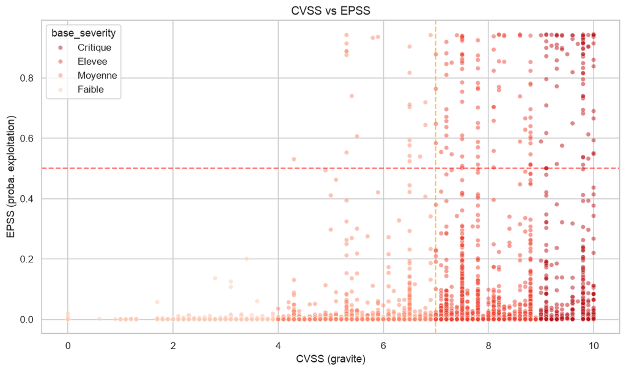

```
Correlation de Pearson CVSS / EPSS : 0.180
```

```python
sub = cve[["cvss", "epss", "base_severity"]].dropna(subset=["cvss", "epss"])
fig, ax = plt.subplots(figsize=(10, 6))
sns.scatterplot(data=sub, x="cvss", y="epss", hue="base_severity",
                hue_order=["Critique", "Elevee", "Moyenne", "Faible"],
                palette="Reds_r", alpha=0.5, s=25, ax=ax)
ax.axhline(0.5, color="red", linestyle="--", alpha=0.6)
ax.axvline(7.0, color="orange", linestyle="--", alpha=0.6)
ax.set_title("CVSS vs EPSS")
ax.set_xlabel("CVSS (gravite)"); ax.set_ylabel("EPSS (proba. exploitation)")
plt.tight_layout(); plt.show()

corr = sub["cvss"].corr(sub["epss"])
print(f"Correlation de Pearson CVSS / EPSS : {corr:.3f}")
```

### 4.5 Croisement CVSS x EPSS (heatmap)

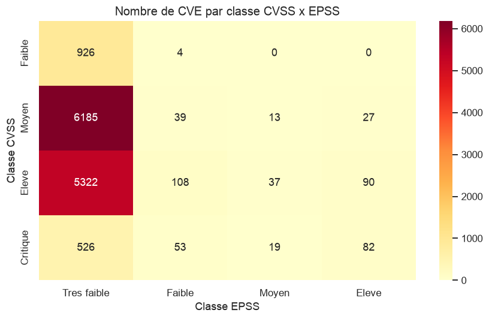

```python
d = cve[["cvss", "epss"]].dropna().copy()
d["CVSS"] = pd.cut(d["cvss"], [0, 4, 7, 9, 10], labels=["Faible", "Moyen", "Eleve", "Critique"])
d["EPSS"] = pd.cut(d["epss"], [0, 0.1, 0.3, 0.5, 1.0],
                   labels=["Tres faible", "Faible", "Moyen", "Eleve"], include_lowest=True)
pivot = d.groupby(["CVSS", "EPSS"], observed=True).size().unstack(fill_value=0)

fig, ax = plt.subplots(figsize=(8, 5))
sns.heatmap(pivot, annot=True, fmt="d", cmap="YlOrRd", ax=ax)
ax.set_title("Nombre de CVE par classe CVSS x EPSS")
ax.set_xlabel("Classe EPSS"); ax.set_ylabel("Classe CVSS")
plt.tight_layout(); plt.show()
```

### 4.6 Editeurs et produits les plus exposes

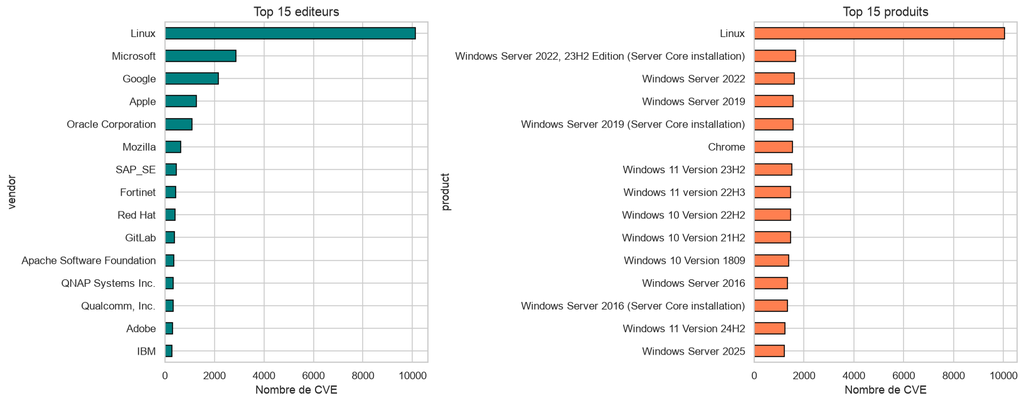

```python
def split_explode(serie):
    s = serie.fillna("").str.split(" | ", regex=False).explode().str.strip()
    return s[(s != "") & (s.str.lower() != "n/a")]

top_editeurs = split_explode(cve["vendor"]).value_counts().head(15)
top_produits = split_explode(cve["product"]).value_counts().head(15)

fig, axes = plt.subplots(1, 2, figsize=(15, 6))
top_editeurs.sort_values().plot(kind="barh", color="teal", edgecolor="black", ax=axes[0])
axes[0].set_title("Top 15 editeurs"); axes[0].set_xlabel("Nombre de CVE")
top_produits.sort_values().plot(kind="barh", color="coral", edgecolor="black", ax=axes[1])
axes[1].set_title("Top 15 produits"); axes[1].set_xlabel("Nombre de CVE")
plt.tight_layout(); plt.show()
```

### 4.7 Types de faiblesses (CWE) les plus frequents

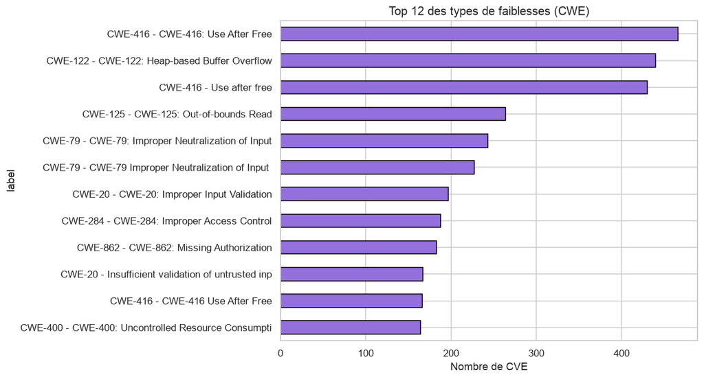

```python
top_cwe = cve.loc[cve["cwe"].notna(), ["cwe", "cwe_desc"]].copy()
top_cwe["label"] = top_cwe["cwe"] + " - " + top_cwe["cwe_desc"].fillna("").str.slice(0, 40)
counts = top_cwe["label"].value_counts().head(12)

fig, ax = plt.subplots(figsize=(11, 6))
counts.sort_values().plot(kind="barh", color="mediumpurple", edgecolor="black", ax=ax)
ax.set_title("Top 12 des types de faiblesses (CWE)")
ax.set_xlabel("Nombre de CVE")
plt.tight_layout(); plt.show()
```

### 4.8 Severite selon le type de faiblesse (CWE)

Toutes les familles de faiblesses ne se valent pas : certaines (corruption memoire, deserialisation) tendent vers des scores plus eleves que d'autres.

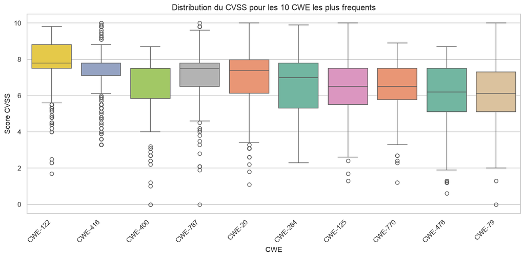

```python
top10_cwe = cve["cwe"].value_counts().head(10).index
box = cve[cve["cwe"].isin(top10_cwe)].dropna(subset=["cvss"])
ordre_cwe = box.groupby("cwe")["cvss"].median().sort_values(ascending=False).index

fig, ax = plt.subplots(figsize=(12, 6))
sns.boxplot(data=box, x="cwe", y="cvss", order=ordre_cwe,
            hue="cwe", palette="Set2", legend=False, ax=ax)
ax.set_title("Distribution du CVSS pour les 10 CWE les plus frequents")
ax.set_xlabel("CWE"); ax.set_ylabel("Score CVSS")
plt.setp(ax.get_xticklabels(), rotation=45, ha="right")
plt.tight_layout(); plt.show()
```

### 4.9 Evolution temporelle des bulletins

On revient ici au niveau **bulletin x CVE** (activite de publication du CERT-FR).

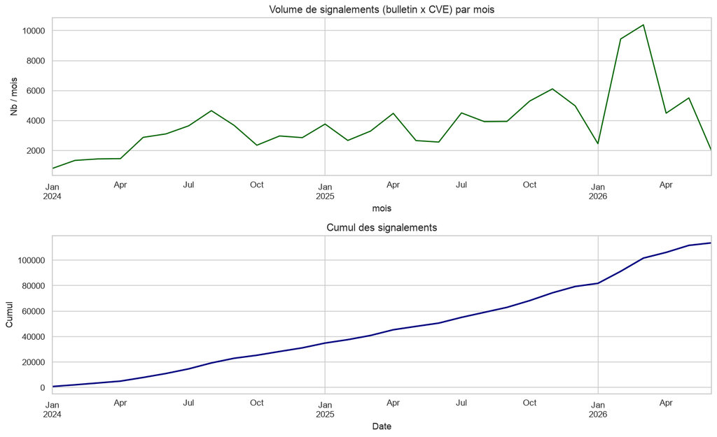

```python
ts = df.dropna(subset=["date"]).copy()
ts["mois"] = ts["date"].dt.to_period("M").dt.to_timestamp()
par_mois = ts.groupby("mois").size()

fig, axes = plt.subplots(2, 1, figsize=(13, 8))
par_mois.plot(ax=axes[0], color="darkgreen", lw=1.5)
axes[0].set_title("Volume de signalements (bulletin x CVE) par mois")
axes[0].set_ylabel("Nb / mois")

par_mois.cumsum().plot(ax=axes[1], color="navy", lw=2)
axes[1].set_title("Cumul des signalements")
axes[1].set_ylabel("Cumul"); axes[1].set_xlabel("Date")
plt.tight_layout(); plt.show()
```

### 4.10 Matrice de correlation des variables numeriques

On ajoute la **longueur de description** comme proxy de la complexite/du detail du bulletin.

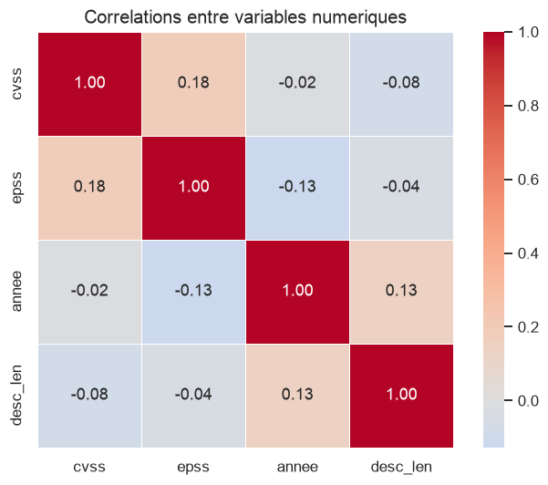

```python
num = cve.assign(desc_len=cve["description"].fillna("").str.len())[
    ["cvss", "epss", "annee", "desc_len"]
].dropna()
fig, ax = plt.subplots(figsize=(6.5, 5))
sns.heatmap(num.corr(), annot=True, fmt=".2f", cmap="coolwarm", center=0,
            square=True, linewidths=0.5, ax=ax)
ax.set_title("Correlations entre variables numeriques")
plt.tight_layout(); plt.show()
```

## 5. Modele supervise : detecter les vulnerabilites de haute severite

*(livrable 3.d - apprentissage supervise)*

### 5.1 Probleme et cible

**Objectif metier** : aider au *triage* en predisant si une vulnerabilite est de **haute severite (CVSS >= 7)** a partir de ses caracteristiques descriptives, **sans utiliser le score CVSS lui-meme**.

- **Cible** `y` : `1` si `CVSS >= 7`, sinon `0`.
- **Variables explicatives** (aucune fuite depuis le CVSS) :
  - texte de la **description** (TF-IDF) ;
  - **CWE** et **type** de bulletin (one-hot) ;
  - **EPSS**, **longueur de description**, **annee** (numeriques).

On travaille au niveau **CVE unique**, sur les CVE disposant d'un CVSS et d'une description.

```python
from sklearn.model_selection import train_test_split, cross_val_score, StratifiedKFold
from sklearn.compose import ColumnTransformer
from sklearn.feature_extraction.text import TfidfVectorizer
from sklearn.preprocessing import OneHotEncoder, StandardScaler
from sklearn.pipeline import Pipeline
from sklearn.linear_model import LogisticRegression
from sklearn.ensemble import RandomForestClassifier
from sklearn.metrics import (classification_report, confusion_matrix,
                             roc_auc_score, roc_curve, ConfusionMatrixDisplay)

ml = cve.dropna(subset=["cvss", "description"]).copy()
ml["desc_len"] = ml["description"].str.len()
ml["epss"] = ml["epss"].fillna(ml["epss"].median())
ml["cwe"] = ml["cwe"].fillna("UNKNOWN")
ml["annee"] = ml["annee"].fillna(ml["annee"].median())
ml["y"] = (ml["cvss"] >= 7).astype(int)

print(f"Echantillon ML : {len(ml):,} CVE")
print("Repartition de la cible (1 = CVSS >= 7) :")
print(ml["y"].value_counts(normalize=True).round(3).to_string())
```

```
Echantillon ML : 13,447 CVE
Repartition de la cible (1 = CVSS >= 7) :
y
0    0.513
1    0.487
```

### 5.2 Pre-traitement et separation train / test

On separe **80 % / 20 %** en stratifiant sur la cible (memes proportions de classes dans chaque jeu). Le pre-traitement (TF-IDF, one-hot, standardisation) est encapsule dans un `ColumnTransformer` integre au pipeline : il est donc appris **uniquement sur le train**, ce qui evite toute fuite de donnees.

```python
features = ["description", "cwe", "type", "epss", "desc_len", "annee"]
X = ml[features]
y = ml["y"]

X_train, X_test, y_train, y_test = train_test_split(
    X, y, test_size=0.2, stratify=y, random_state=RANDOM_STATE
)

pretraitement = ColumnTransformer([
    ("txt", TfidfVectorizer(max_features=2000, stop_words="english",
                            ngram_range=(1, 2), min_df=5), "description"),
    ("cat", OneHotEncoder(handle_unknown="ignore", min_frequency=20), ["cwe", "type"]),
    ("num", StandardScaler(), ["epss", "desc_len", "annee"]),
])

print(f"Train : {len(X_train):,} | Test : {len(X_test):,}")
```

```
Train : 10,757 | Test : 2,690
```

### 5.3 Entrainement de deux modeles

On compare un modele **lineaire interpretable** (regression logistique) et un modele **ensembliste non lineaire** (forets aleatoires). `class_weight="balanced"` compense le leger desequilibre des classes.

```python
modeles = {
    "Regression logistique": LogisticRegression(max_iter=1000, class_weight="balanced"),
    "Foret aleatoire": RandomForestClassifier(
        n_estimators=200, max_depth=None, n_jobs=-1,
        class_weight="balanced", random_state=RANDOM_STATE),
}

resultats = {}
for nom, clf in modeles.items():
    pipe = Pipeline([("prep", pretraitement), ("clf", clf)])
    pipe.fit(X_train, y_train)
    proba = pipe.predict_proba(X_test)[:, 1]
    pred = pipe.predict(X_test)
    auc = roc_auc_score(y_test, proba)
    resultats[nom] = {"pipe": pipe, "pred": pred, "proba": proba, "auc": auc}
    print(f"=== {nom} ===  ROC-AUC = {auc:.3f}")
    print(classification_report(y_test, pred, target_names=["CVSS < 7", "CVSS >= 7"]))
```

```
=== Regression logistique ===  ROC-AUC = 0.885
              precision    recall  f1-score   support

    CVSS < 7       0.79      0.84      0.82      1379
   CVSS >= 7       0.82      0.77      0.79      1311

    accuracy                           0.81      2690
   macro avg       0.81      0.81      0.81      2690
weighted avg       0.81      0.81      0.81      2690
```

```
=== Foret aleatoire ===  ROC-AUC = 0.918
              precision    recall  f1-score   support

    CVSS < 7       0.82      0.88      0.85      1379
   CVSS >= 7       0.86      0.79      0.83      1311

    accuracy                           0.84      2690
   macro avg       0.84      0.84      0.84      2690
weighted avg       0.84      0.84      0.84      2690
```

### 5.4 Validation du modele supervise

*(livrable 3.e)*

On valide via : **matrice de confusion**, **courbes ROC** comparees, et **validation croisee 5 plis** (robustesse de la performance).

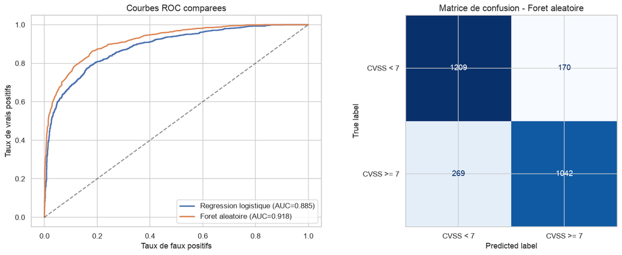

```
Meilleur modele (ROC-AUC) : Foret aleatoire
```

```python
fig, axes = plt.subplots(1, 2, figsize=(14, 5.5))

# Matrices de confusion
for ax, (nom, r) in zip([axes[0]], list(resultats.items())[:1]):
    pass

# (a) Courbes ROC comparees
for nom, r in resultats.items():
    fpr, tpr, _ = roc_curve(y_test, r["proba"])
    axes[0].plot(fpr, tpr, lw=2, label=f"{nom} (AUC={r['auc']:.3f})")
axes[0].plot([0, 1], [0, 1], "k--", alpha=0.5)
axes[0].set_xlabel("Taux de faux positifs"); axes[0].set_ylabel("Taux de vrais positifs")
axes[0].set_title("Courbes ROC comparees"); axes[0].legend(loc="lower right")

# (b) Matrice de confusion du meilleur modele
best_nom = max(resultats, key=lambda n: resultats[n]["auc"])
cm = confusion_matrix(y_test, resultats[best_nom]["pred"])
ConfusionMatrixDisplay(cm, display_labels=["CVSS < 7", "CVSS >= 7"]).plot(
    ax=axes[1], cmap="Blues", colorbar=False)
axes[1].set_title(f"Matrice de confusion - {best_nom}")
plt.tight_layout(); plt.show()

print(f"Meilleur modele (ROC-AUC) : {best_nom}")
```

```python
# Validation croisee 5 plis (stratifiee) sur le meilleur modele
cv = StratifiedKFold(n_splits=5, shuffle=True, random_state=RANDOM_STATE)
scores = cross_val_score(resultats[best_nom]["pipe"], X, y, cv=cv,
                         scoring="roc_auc", n_jobs=-1)
print(f"ROC-AUC en validation croisee (5 plis) : "
      f"{scores.mean():.3f} +/- {scores.std():.3f}")
print("Plis :", np.round(scores, 3))
```

```
ROC-AUC en validation croisee (5 plis) : 0.916 +/- 0.006
Plis : [0.92  0.911 0.919 0.906 0.922]
```

### 5.5 Interpretation : mots les plus discriminants

La regression logistique etant lineaire, ses coefficients indiquent quels termes de la description poussent vers la **haute severite** (positifs) ou vers une severite plus faible (negatifs).

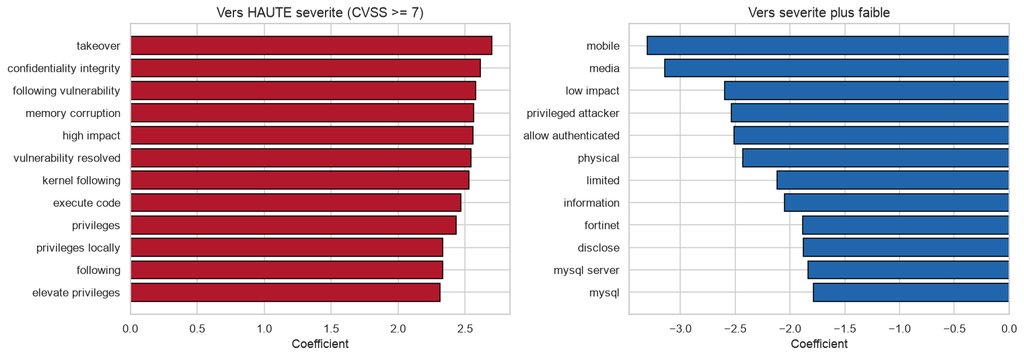

```python
logreg = resultats["Regression logistique"]["pipe"]
noms_tfidf = logreg.named_steps["prep"].named_transformers_["txt"].get_feature_names_out()
coefs = logreg.named_steps["clf"].coef_[0][:len(noms_tfidf)]

ordre = np.argsort(coefs)
top_pos = [(noms_tfidf[i], coefs[i]) for i in ordre[-12:]][::-1]
top_neg = [(noms_tfidf[i], coefs[i]) for i in ordre[:12]]

fig, axes = plt.subplots(1, 2, figsize=(14, 5))
for ax, data, titre, col in [
    (axes[0], top_pos, "Vers HAUTE severite (CVSS >= 7)", "#b2182b"),
    (axes[1], top_neg, "Vers severite plus faible", "#2166ac"),
]:
    mots = [m for m, _ in data][::-1]
    vals = [c for _, c in data][::-1]
    ax.barh(mots, vals, color=col, edgecolor="black")
    ax.set_title(titre); ax.set_xlabel("Coefficient")
plt.tight_layout(); plt.show()
```

## 6. Modele non supervise : segmentation des vulnerabilites

*(livrable 3.d - apprentissage non supervise)*

### 6.1 Objectif

Sans etiquette, on cherche a **regrouper les vulnerabilites en profils de risque** homogenes a partir des deux axes metier complementaires, **standardises** : le **CVSS** (gravite) et l'**EPSS** (probabilite d'exploitation). Algorithme : **KMeans**. Travailler dans ce plan rend les clusters directement interpretables (et visualisables sans projection).

```python
from sklearn.cluster import KMeans
from sklearn.preprocessing import StandardScaler
from sklearn.metrics import silhouette_score, davies_bouldin_score

clu = cve.dropna(subset=["cvss", "epss"]).copy()
X_clu = clu[["cvss", "epss"]].to_numpy()

scaler = StandardScaler()
X_scaled = scaler.fit_transform(X_clu)
print(f"Donnees de clustering : {X_scaled.shape[0]:,} CVE x {X_scaled.shape[1]} variables (CVSS, EPSS)")
```

```
Donnees de clustering : 13,442 CVE x 2 variables (CVSS, EPSS)
```

### 6.2 Choix du nombre de clusters (validation)

*(livrable 3.e)*

On combine deux criteres sur `k = 2..8` :

- la **methode du coude** (inertie intra-cluster) ;
- le **score de silhouette** (a maximiser ; mesure la separation des clusters).

> Le silhouette est maximal en `k = 2` : l'EPSS etant tres asymetrique (masse de CVE non exploitees), les donnees se separent d'abord grossierement en *exploitee / non exploitee*. Pour une segmentation **operationnelle plus fine** on retient `k = 4`, dont la silhouette reste correcte (~0,5) — un compromis assume entre separation statistique et granularite metier.

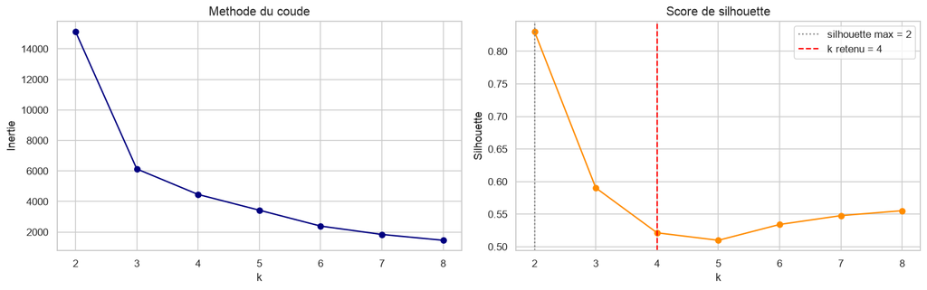

```
Silhouette maximale en k=2 (0.830)
k retenu pour la segmentation metier : 4 (silhouette 0.521)
```

```python
ks = range(2, 9)
inerties, silhouettes = [], []
for k in ks:
    km = KMeans(n_clusters=k, n_init=10, random_state=RANDOM_STATE)
    labels = km.fit_predict(X_scaled)
    inerties.append(km.inertia_)
    silhouettes.append(silhouette_score(X_scaled, labels))

fig, axes = plt.subplots(1, 2, figsize=(14, 4.5))
axes[0].plot(list(ks), inerties, "o-", color="navy")
axes[0].set_title("Methode du coude"); axes[0].set_xlabel("k"); axes[0].set_ylabel("Inertie")
axes[1].plot(list(ks), silhouettes, "o-", color="darkorange")
axes[1].set_title("Score de silhouette"); axes[1].set_xlabel("k"); axes[1].set_ylabel("Silhouette")
best_k = list(ks)[int(np.argmax(silhouettes))]
K_RETENU = 4  # choix metier (cf. ci-dessus)
axes[1].axvline(best_k, color="gray", linestyle=":", label=f"silhouette max = {best_k}")
axes[1].axvline(K_RETENU, color="red", linestyle="--", label=f"k retenu = {K_RETENU}")
axes[1].legend()
plt.tight_layout(); plt.show()

sil_dict = dict(zip(ks, silhouettes))
print(f"Silhouette maximale en k={best_k} ({sil_dict[best_k]:.3f})")
print(f"k retenu pour la segmentation metier : {K_RETENU} (silhouette {sil_dict[K_RETENU]:.3f})")
```

### 6.3 Clustering final et validation des indices

```python
kmeans = KMeans(n_clusters=K_RETENU, n_init=10, random_state=RANDOM_STATE)
clu["cluster"] = kmeans.fit_predict(X_scaled)

sil = silhouette_score(X_scaled, clu["cluster"])
db = davies_bouldin_score(X_scaled, clu["cluster"])
print(f"Silhouette       : {sil:.3f}  (plus c'est haut, mieux c'est)")
print(f"Davies-Bouldin   : {db:.3f}  (plus c'est bas, mieux c'est)")
print(f"Taille des clusters :\n{clu['cluster'].value_counts().sort_index().to_string()}")
```

```
Silhouette       : 0.521  (plus c'est haut, mieux c'est)
Davies-Bouldin   : 0.550  (plus c'est bas, mieux c'est)
Taille des clusters :
cluster
0    6489
1    1731
2     241
3    4981
```

### 6.4 Visualisation des clusters

Les variables etant les deux axes metier, on lit directement les clusters dans le plan **CVSS x EPSS** (echelle lineaire puis logarithmique pour detailler la zone des faibles EPSS, ou se concentre la majorite des CVE).

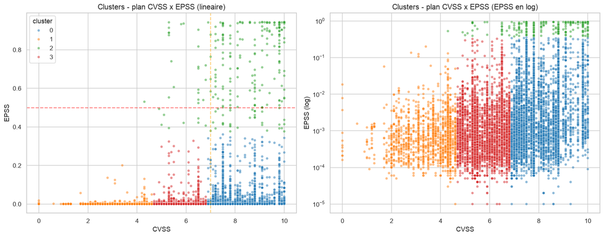

```python
fig, axes = plt.subplots(1, 2, figsize=(15, 6))
sns.scatterplot(data=clu, x="cvss", y="epss", hue="cluster",
                palette="tab10", alpha=0.5, s=20, ax=axes[0], legend="full")
axes[0].axvline(7, color="orange", ls="--", alpha=0.5); axes[0].axhline(0.5, color="red", ls="--", alpha=0.5)
axes[0].set_title("Clusters - plan CVSS x EPSS (lineaire)")
axes[0].set_xlabel("CVSS"); axes[0].set_ylabel("EPSS")

sns.scatterplot(data=clu[clu["epss"] > 0], x="cvss", y="epss", hue="cluster",
                palette="tab10", alpha=0.5, s=20, ax=axes[1], legend=False)
axes[1].set_yscale("log")
axes[1].set_title("Clusters - plan CVSS x EPSS (EPSS en log)")
axes[1].set_xlabel("CVSS"); axes[1].set_ylabel("EPSS (log)")
plt.tight_layout(); plt.show()
```

### 6.5 Profil et interpretation des clusters

On caracterise chaque cluster par les valeurs **moyennes** de ses variables pour lui donner un sens metier (ex. *grave & exploitee*, *grave peu exploitee*...).

| cluster | n_cve | cvss_moyen | epss_moyen | pct | profil_metier |
| --- | --- | --- | --- | --- | --- |
| 0 | 6489 | 7.975 | 0.013 | 48.3 | Grave mais peu exploitee (a corriger) |
| 1 | 1731 | 3.572 | 0.002 | 12.9 | Faible priorite |
| 2 | 241 | 8.329 | 0.715 | 1.8 | Critique : grave ET exploitee (priorite absolue) |
| 3 | 4981 | 5.779 | 0.004 | 37.1 | Faible priorite |

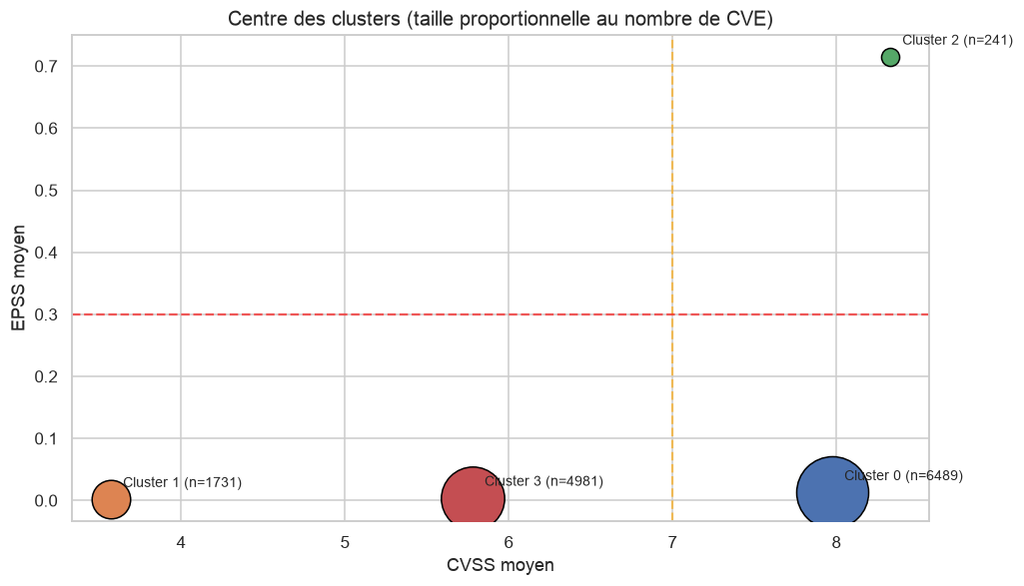

```python
profil = clu.groupby("cluster").agg(
    n_cve=("cve", "size"),
    cvss_moyen=("cvss", "mean"),
    epss_moyen=("epss", "mean"),
).round(3)
profil["pct"] = (profil["n_cve"] / len(clu) * 100).round(1)

def nommer(row):
    grave = row["cvss_moyen"] >= 7
    exploite = row["epss_moyen"] >= 0.3
    if grave and exploite:
        return "Critique : grave ET exploitee (priorite absolue)"
    if grave:
        return "Grave mais peu exploitee (a corriger)"
    if exploite:
        return "Exploitee mais moins grave (a surveiller)"
    return "Faible priorite"

profil["profil_metier"] = profil.apply(nommer, axis=1)
display(profil)

fig, ax = plt.subplots(figsize=(9.5, 5.5))
for c, row in profil.iterrows():
    ax.scatter(row["cvss_moyen"], row["epss_moyen"], s=row["n_cve"] / 3 + 60,
               edgecolor="black", zorder=3)
    ax.annotate(f"Cluster {c} (n={int(row['n_cve'])})",
                (row["cvss_moyen"], row["epss_moyen"]),
                textcoords="offset points", xytext=(8, 8), fontsize=9)
ax.axvline(7, color="orange", ls="--", alpha=0.6); ax.axhline(0.3, color="red", ls="--", alpha=0.6)
ax.set_xlabel("CVSS moyen"); ax.set_ylabel("EPSS moyen")
ax.set_title("Centre des clusters (taille proportionnelle au nombre de CVE)")
plt.tight_layout(); plt.show()
```

## 7. Conclusion

**Donnees.** Le pipeline consolide les bulletins du CERT-FR enrichis par MITRE (CVSS, CWE, produits) et FIRST (EPSS). Apres dedoublonnage, on dispose de plusieurs milliers de CVE uniques exploitables.

**Analyses.** Gravite (CVSS) et probabilite d'exploitation (EPSS) sont faiblement correlees : prioriser uniquement sur le CVSS laisse passer des vulnerabilites peu graves mais activement exploitees. Quelques editeurs et familles de faiblesses (CWE) concentrent une part importante des signalements.

**Modele supervise.** Un classifieur (TF-IDF de la description + CWE/type + EPSS) predit la haute severite (CVSS >= 7) avec un bon ROC-AUC, confirme en validation croisee 5 plis. Les coefficients revelent les termes (corruption memoire, execution de code...) annonciateurs d'une forte gravite.

**Modele non supervise.** KMeans (k=4, valide par silhouette / Davies-Bouldin) degage dans le plan CVSS x EPSS des **profils de risque** distincts : du petit cluster *grave ET activement exploite* (priorite absolue) aux vulnerabilites de moindre priorite. C'est une aide directe au triage, complementaire des seuils d'alerte du pipeline.

> **Pistes** : ajuster les seuils d'alerte par cluster, enrichir le texte (KEV/CISA), tester des modeles de gradient boosting, suivre la derive temporelle des profils.